# Package {tod} - Banque HYDRO

Pascal Irz

2021-02-12

Les étapes de configuration de la machine et d’installation des packages sont considérées comme déjà réalisées.

La présentation générale du `package {tod}` est disponible [ici](https://rpubs.com/kamoke/723467).

Activation des `packages`.

```r
library(tod)
library(tidyverse)
```

# Contenu

Ces données sont mises à disposition par l’[API Hub’Eau - Hydrométrie](https://hubeau.eaufrance.fr/page/api-hydrometrie).

Le référentiel associé est [disponible en ligne](https://www.sandre.eaufrance.fr/notice-doc/r%C3%A9f%C3%A9rentiel-hydrom%C3%A9trique-3).

La plupart des données sont rattachées à un site ou à une station de mesure. La sélection des stations peut être opérée de diverses manières :

- Liste des codes des stations (encore faut-il les connaître)
- Sélection géographique soit rectangulaire (`bbox`) soit circulaire (en indiquant les coordonnées du point central et un rayon)
- Parfois sur l’appartenance à une entité administrative identifiée par son [Code Officiel Géographique (COG)](https://www.data.gouv.fr/fr/datasets/code-officiel-geographique-cog/).

L’API comprend plusieurs limitations :

- Elle ne permet pas de remonter au-delà d’un mois.
- Elle limite le téléchargement à 20 000 données par requête.
- Quand le téléchargement comporte plusieurs stations, le pas de temps `timestep` n’est plus activé donc on est contraints au pas de 10’ par défaut, et par conséquent à des chroniques avec 6 fois moins de longueur que si l’on avait `timestep = 60`.

> Il se peut aussi qu’au bout d’un moment un message d’erreur “HTTP error 502” ou “504” vous soit retourné.

Dans ce cas des codes erreurs dans la gamme des 500, c’est le serveur qui n’a pas réussi à traiter correctement votre requête ou que la connexion est mauvaise. **Normalement en recommençant ça finit par passer**.

Les fonctions du `package` utilisées ici sont toutes préfixées `menv_bh` en référence au founrisseur de la donnée, le Ministère de l’Environnement (`menv`) et à la source, la banque HYDRO (`bh`).

# Caractéristiques des stations

L’API donne accès à certaines données basiques sur les stations HYDRO. Il est possible de sélectionner les stations sur divers critères qui sont expliqués sur [la page de l’API](https://hubeau.eaufrance.fr/page/api-hydrometrie#/hydrometrie/sites). Par exemple, on peut sélectionner selon un rectangle géographique. Dans ce cas le format est imposé :

- Ordre de saisie “min longitude, min latitude, max longitude, max latitude”
- Coordonnées en WGS84 (EPSG:4326)
- Séparateur décimal

```r
donnees_stations <- menv_bh_sta_tod(bbox = "-7, 46, -3, 48")
```

Autre exemple, si l’on s’intéresse aux stations de la région Bretagne (code Insee = 53) :

```r
donnees_stations <- menv_bh_sta_tod(code_region = 53)
```

On obtient un tableau de 215 lignes et 35 colonnes nommées :

```r
names(donnees_stations)
```

```
#>  [1] "code_site"                           "libelle_site"
#>  [3] "type_site"                           "coordonnee_x_site"
#>  [5] "coordonnee_y_site"                   "code_projection"
#>  [7] "longitude_site"                      "latitude_site"
#>  [9] "altitude_site"                       "code_systeme_alti_site"
#> [11] "surface_bv"                          "statut_site"
#> [13] "premier_mois_etiage_site"            "premier_mois_annee_hydro_site"
#> [15] "influence_generale_site"             "code_entite_hydro_site"
#> [17] "code_troncon_hydro_site"             "code_commune_site"
#> [19] "code_zone_hydro_site"                "libelle_commune"
#> [21] "code_departement"                    "code_region"
#> [23] "libelle_region"                      "code_cours_eau"
#> [25] "libelle_cours_eau"                   "uri_cours_eau"
#> [27] "grandeur_hydro"                      "date_maj_site"
#> [29] "date_premiere_donnee_dispo_site"     "commentaire_influence_generale_site"
#> [31] "commentaire_site"                    "type_contexte_loi_stat_site"
#> [33] "type_loi_site"                       "libelle_departement"
#> [35] "geometry"
```

Les premières lignes contiennent par exemple les informations suivantes (sélection de colonnes) :

```r
donnees_stations %>% select(code_site,
                            libelle_site,
                            longitude_site,
                            latitude_site,
                            altitude_site,
                            surface_bv,
                            code_departement) %>%
  head() %>% # uniquement les premières lignes
  DT::datatable()
```

|  | code_site | libelle_site | longitude_site | latitude_site | altitude_site | surface_bv | code_departement |
| --- | --- | --- | --- | --- | --- | --- | --- |
| 1 | I9122010 | L'Airon à Louvigné-du-Désert et à Landivy | -1.071908022 | 48.486959222 | 108 | 149.7 | ['35', '53'] |
| 2 | J0014010 | Le Nançon à Lécousse | -1.196450736 | 48.375583015 | 105 | 64.45 | ['35', '35'] |
| 3 | J0101510 | Le Couesnon à Mézières-sur-Couesnon | -1.430750755 | 48.312096249 | 45 | 372.1 | 35 |
| 4 | J0121510 | Le Couesnon à Romazy | -1.503785903 | 48.365470791 | 20 | 517.04 | 35 |
| 5 | J0144010 | La Loisance à Saint-Ouen-la-Rouërie | -1.435815393 | 48.427932361 | 50 | 82.1 | 35 |
| 6 | J0144210 | La Loisance à Saint-Étienne-en-Coglès | -1.323686429 | 48.406523314 | 60 | 28.23 | 35 |

# Hydrologie en temps réel

Ces données de hauteur d’eau et de débit sont mises à disposition par le module [Opérations sur les niveaux et les débits des cours d’eau en temps réel](https://hubeau.eaufrance.fr/page/api-hydrometrie#/hydrometrie/observations) de l’API Hub’Eau - Hydrométrie. Elles se rapportent à la station de mesure.

## Pour une station

### Téléchargement

Pour collecter les données associées à une station dont on connaît l’identifiant, on utilise la fonction `menv_bh_htr_tod()` qui, par défaut, renvoie les données de débit et de hauteur.

```r
ma_station <- "J0121510"
data_sta <- menv_bh_htr_tod(stations_id = ma_station)
```

On peut aussi avoir besoin du débit (mesure = “Q”) et non de la hauteur d’eau (mesure = “H”) :

```r
data_sta <- menv_bh_htr_tod(stations_id = ma_station,
                            grandeur_hydro = "Q")
```

Par défaut, la fonction renvoie les 20 000 dernières données.

### Structure du tableau

Visualisation des premières lignes du tableau.

```r
data_sta %>%
  head() %>%
  DT::datatable()
```

|  | code_site | code_station | grandeur_hydro | date_debut_serie | date_fin_serie | statut_serie | code_systeme_alti_serie | date_obs | resultat_obs | code_methode_obs | libelle_methode_obs | code_qualification_obs | libelle_qualification_obs | continuite_obs_hydro | longitude | latitude |
| --- | --- | --- | --- | --- | --- | --- | --- | --- | --- | --- | --- | --- | --- | --- | --- | --- |
| 1 | J0121510 | J012151001 | Q | 2021-02-12T00:12:01Z | 2021-02-12T09:12:00Z | 4 | 31 | 2021-02-12T09:12:00Z | 10776 | 12 | Interpolation | 16 | Non qualifiée | True | -1.503785903 | 48.365470791 |
| 2 | J0121510 | J012151001 | Q | 2021-02-12T00:12:01Z | 2021-02-12T09:12:00Z | 4 | 31 | 2021-02-12T09:06:00Z | 10776 | 12 | Interpolation | 16 | Non qualifiée | True | -1.503785903 | 48.365470791 |
| 3 | J0121510 | J012151001 | Q | 2021-02-12T00:12:01Z | 2021-02-12T08:12:00Z | 4 | 31 | 2021-02-12T08:06:00Z | 10753 | 12 | Interpolation | 16 | Non qualifiée | True | -1.503785903 | 48.365470791 |
| 4 | J0121510 | J012151001 | Q | 2021-02-12T00:12:01Z | 2021-02-12T07:12:00Z | 4 | 31 | 2021-02-12T07:06:00Z | 10753 | 12 | Interpolation | 16 | Non qualifiée | True | -1.503785903 | 48.365470791 |
| 5 | J0121510 | J012151001 | Q | 2021-02-12T00:12:01Z | 2021-02-12T06:12:00Z | 4 | 31 | 2021-02-12T06:06:00Z | 10799 | 12 | Interpolation | 16 | Non qualifiée | True | -1.503785903 | 48.365470791 |
| 6 | J0121510 | J012151001 | Q | 2021-02-12T00:12:01Z | 2021-02-12T05:12:00Z | 4 | 31 | 2021-02-12T05:06:00Z | 10799 | 12 | Interpolation | 16 | Non qualifiée | True | -1.503785903 | 48.365470791 |

### Représentation graphique

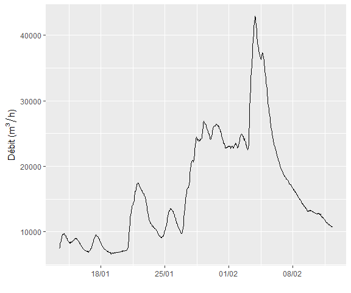

```r
data_sta <- data_sta %>%
  mutate(date_obs = lubridate::ymd_hms(date_obs)) # format de la date

ggplot(data = data_sta, aes(x = date_obs, y = resultat_obs)) +
  geom_line() +
  scale_x_datetime(date_labels = "%d/%m") + # étiquette axe des dates
  labs(x = "", y = bquote('Débit ('*m^3/h*')')) # légendes des axes
```

## Pour plusieurs stations

### Sélection des stations

En reprenant la sélection géographique rectangulaire précédente des stations, on peut collecter les identifiants des stations. On peut aussi procéder à partir du département :

```r
stations <- menv_bh_sta_tod(code_departement = 22)
```

Les identifiants de ces stations sont les suivants :

```r
stations_id <- stations %>%
  pull(code_site)  %>%
  unique()
```

Où sont-elles situées ?

```r
stations %>%
  sf::st_as_sf(coords = c("longitude_site", "latitude_site"), crs = 4326) %>%
  mapview::mapview(map.types = "OpenStreetMap")
```

[interactive chart not shown]

### Collecte des données hydrologiques

La fonction `menv_bh_htr_tod()` permet de contourner certaines des limitations de l’API pour collecter, sur un jeu de plusieurs stations, jusqu’à 20 000 mesures **par station** et en fixant le paramètre `timestep`, par exemple à `timestep = 60` pour un pas de temps d’une heure.

Pour l’utiliser, il faut les identifiants des stations regroupés en un vecteur.

```r
stations_id <- stations %>%
  pull(code_site) %>%
  unique
```

Vérification du contenu de l’objet `stations_id` :

```r
length(stations_id) # nb d'élements
```

```
#> [1] 49
```

```r
class(stations_id) # classe du vecteur
```

```
#> [1] "character"
```

Chargement des données.

> NB Cette étape prend de une à quelques secondes par station. C’est ici que les erreurs ‘500’ sont les plus fréquentes. Dans ce cas, recommencer.

```r
debits_plusieurs_stations <- menv_bh_htr_tod(stations_id = stations_id) %>%
  mutate(date_obs = lubridate::ymd_hms(date_obs)) %>%  # format de la date
  left_join(y = stations %>% select(code_site, libelle_site))
```

Combien de données par station ?

```r
nb_donnees_par_sta <-
  debits_plusieurs_stations %>%
  pull(libelle_site) %>%
  table() %>%
  as.data.frame()

DT::datatable(nb_donnees_par_sta)
```

|  | . | Freq |
| --- | --- | --- |
| 1 | L'Arguenon à Jugon-les-Lacs | 720 |
| 2 | L'Evron à Coëtmieux | 720 |
| 3 | L'Hyère à Trébrivan | 720 |
| 4 | L'Ic à Binic | 719 |
| 5 | L'Oust à Hémonstoir | 720 |
| 6 | L'Oust à Saint-Martin-des-Prés | 720 |
| 7 | L'Urne à Plédran | 720 |
| 8 | La Maudouve à Saint-Donan | 720 |
| 9 | La Rance à Saint-Jouan-de-l'Isle | 720 |
| 10 | La Rosette à Mégrit | 720 |

[output cut: 22 more lines]

Il apparaît donc que sur les 49 stations initialement sélectionnées, seulement 32 fournissent des données sur la période considérée.

### Représentation graphique

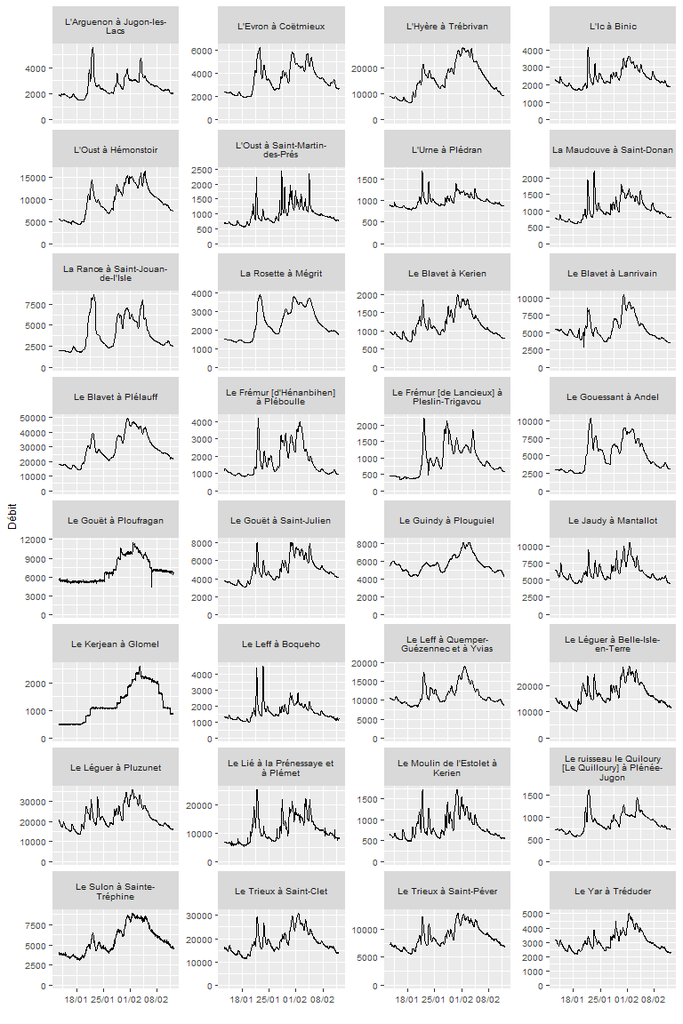

```r
ggplot(data = debits_plusieurs_stations, aes(x = date_obs, y = resultat_obs)) +
  geom_line() +
  scale_x_datetime(date_labels = "%d/%m") + # étiquette axe des dates
  labs(x = "", y = "Débit") + # légendes des axes
  facet_wrap( ~ str_wrap(libelle_site, 25), # renvoi à la ligne si les noms des stations sont longs
              scales = 'free_y', # l'échelle verticale est différente pour chaque station
              ncol = 4) + # nb de colonnes
  coord_cartesian(ylim = c(0, NA)) + # l'axe des débits commence à zéro
  theme(text = element_text(size = 9)) # taille de la police
```